# Trabajo Final

Jean Paul Yepes, Evelyn Bermudez Bedoya, Paula Andrea Cifuentes David, Alejandro Santamaria Espinosa, Elver Tunubala Yalanda

# Obtención de resultados con los puntos dibujados

En esta sección se mostraran los resultados de los puntos dibujados, se mostrará la transformación de los puntos a coordenadas, resultados K de Ripley, elaboración de un puntaje para mostrar las personas que tuvieron un comportamiento mas aleatorio.

# Muestra de los resultados de detección de puntos

En esta imagen se ve la precisión que se alcanza al obtener las coordenadas los puntos, se puede ver que los resultados coinciden con lo que se espera, localiza correctamente la ubicación y la cantidad. En esta etapa de obtención se eliminaron algunas imagenes en las cuales los puntos no estaban claramente diferenciados, o que los encuestados dibujaron mal, con lo que esta muestra cuenta con 53 imágenes.

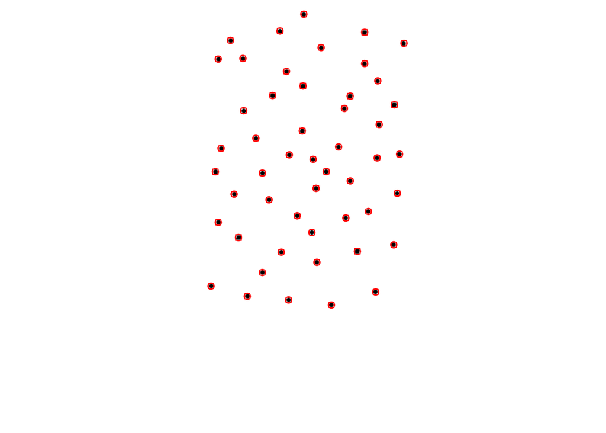

# Resultados K de Ripley

Del intervalo de confianza se puede ver que la tendencia de las personas es a agrupar los puntos que dibujan, por lo tanto no es un comportamiento aleatorio, sino que se rige por un patrón que se ve evidenciado en el resultado.

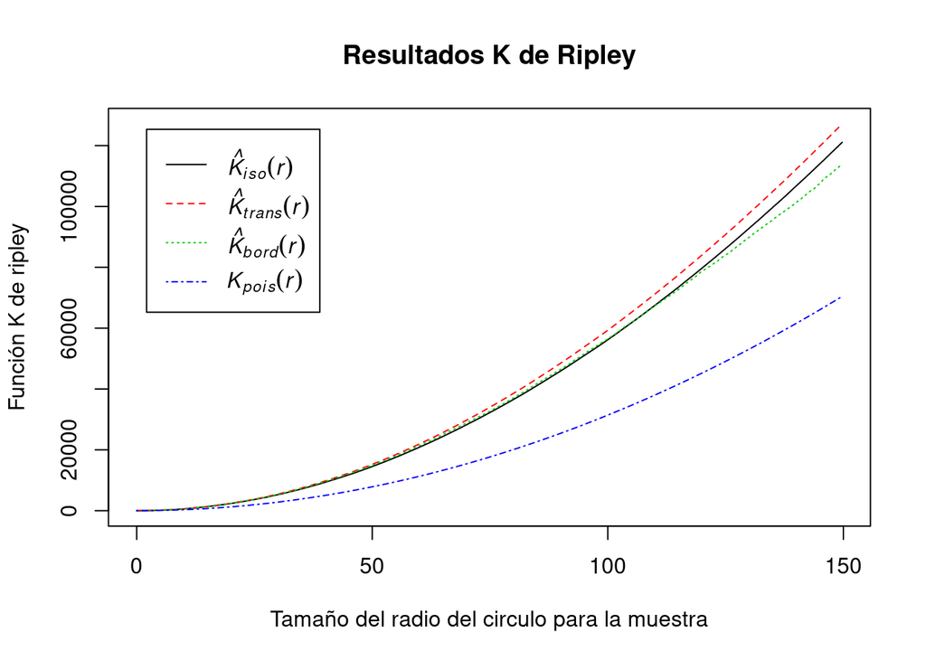

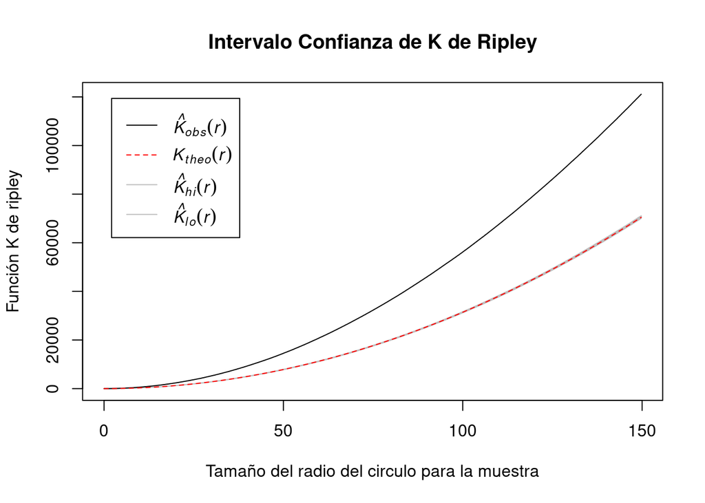

# Puntos dibujados por los encuestados

Viendo lo que las personas dibujaron en su concepto puntos aleatorios, se puede ver que esto no es así, ellos siguen un patrón , ellos suelen dibujar los puntos en la mitad izquierda y con mas intensidad en la esquina izquierda, esto quiere decir que los humanos somos malos emulando un comportamiento aleatorio.

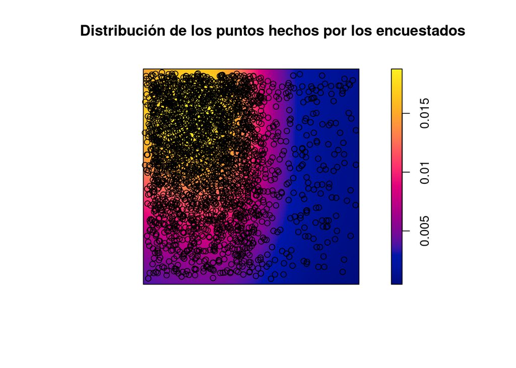

# Métrica definida para aletoriedad

Para calcular el puntaje de aletoriedad, se hizo por la suma de las distancias verticales, en los resultados de los intervalos de confianza individuales hechos en cada K de Ripley, con simulaciones hechas por la misma semilla para garantizar que se obtengan los mismos resultados. En esta métrica 0 es un comportamiento aleatorio, un resultado positivo es que se tiende al agrupamiento y un resultado negativo es que se tiende a la uniformidad.

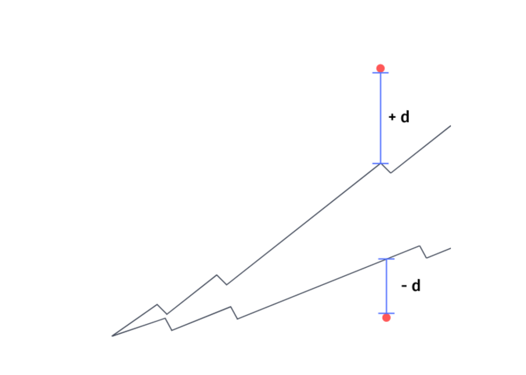

# Datos de las 5 personas mas aleatorias bajo esta metrica

| Escriba.un.numero.entre.0.9 | Seleccione.su.género | Seleccione.un.nivel.de.estudio | X.Cuantos.años.tiene. | Seleccione.un.área.del.conocimiento | X.Cree.que.los.seres.humanos.tenemos.un.destino.escrito. | X.Usted.se.considera.una.persona.religiosa. | score |
| --- | --- | --- | --- | --- | --- | --- | --- |
| 7 | Masculino | Pregrado | 20 | Economia, administracion, contaduria | Si | No | 0.0 |
| 9 | Masculino | Tecnica | 27 | Matematicas, ciencias naturales | Si | Si | 170576.4 |
| 5 | Femenino | Tecnica | 20 | Ciencias de la salud | No | No | -278465.8 |
| 0 | Masculino | Pregrado | 22 | Ingenieria, arquitectura, urbanismo | No | No | -351340.9 |
| 4 | Masculino | Pregrado | 22 | Ingenieria, arquitectura, urbanismo | No | No | 390222.6 |

# Resultado K de Ripley persona mas aleatoria

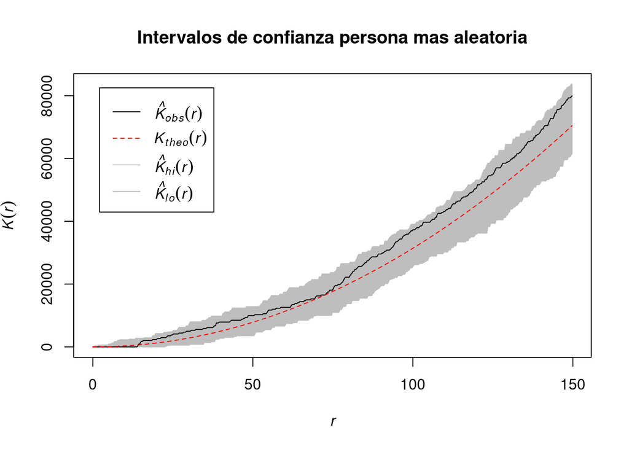

# Puntos dibujados por la persona mas aleatoria

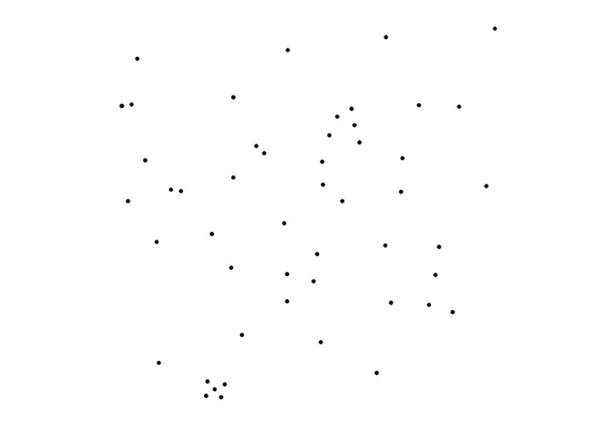

# Caracterización de la muestra

## Género

Esta fue una pregunta que se le realizó a las personas para saber que cantidad de hombres y mujeres realizaron la encuesta, en la cuál se obtuvieron los siguientes resultados

### Tabla de frecuencias

```
##
##  Femenino Masculino
##        37        26
```

### Tabla de frecuencias de porcentajes

```
##
##  Femenino Masculino
##  58.73016  41.26984
```

### Gráfica

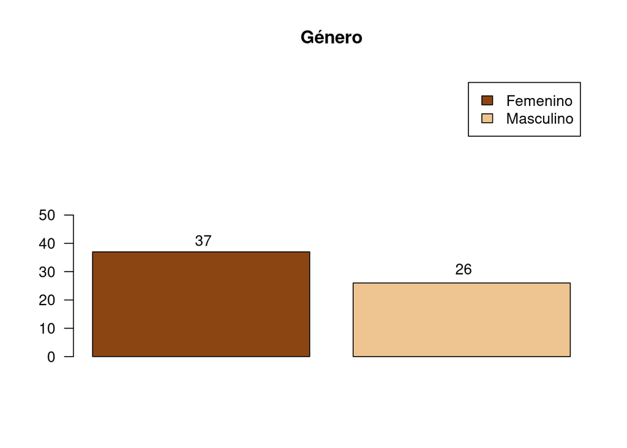

En esta gráfica podemos observar que en total fueron 63 personas las que pudieron contestar la encuesta, repartidos de la siguiente manera: 37 mujeres, y 26 hombres.

## ¿Cuantos años tiene?

Esta fue una de las preguntas que realizamos en la encuesta y como se observar, tuvimos personas de casi todas la edades, esta,no fue dirigida solo hacia un grupo de personas sino que tuvimos encuenta apersonas mayores.

### Tabla de frecuencias

```
##
## 18 19 20 21 22 23 24 25 26 27 28 30 31 32 34 35 36 37 40 44 50 52 60 62
##  1  7  5  7  8  3  4  4  3  1  3  3  1  1  2  1  1  1  1  1  1  2  1  1
```

### Tabla de frecuencias de porcentajes

```
##
##        18        19        20        21        22        23        24        25
##  1.587302 11.111111  7.936508 11.111111 12.698413  4.761905  6.349206  6.349206
##        26        27        28        30        31        32        34        35
##  4.761905  1.587302  4.761905  4.761905  1.587302  1.587302  3.174603  1.587302
##        36        37        40        44        50        52        60        62
##  1.587302  1.587302  1.587302  1.587302  1.587302  3.174603  1.587302  1.587302
```

### Gráfica

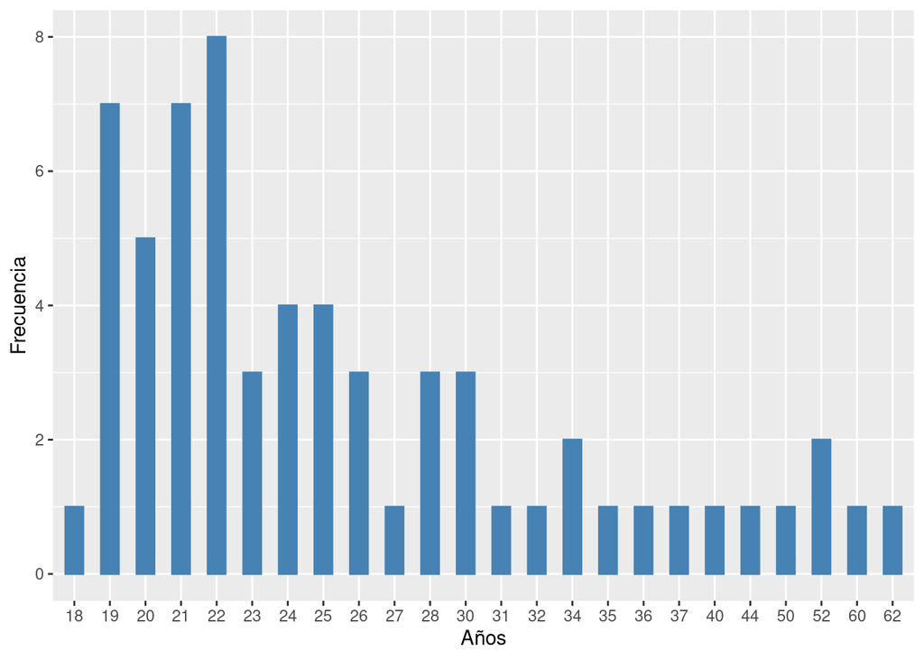

## Nivel de estudio

En esta pregunta se busca saber de las 63 personas que respondieron la encuesta que nivel de estudio tienen, obteniendo los siguientes resultados:

### Tabla de frecuencias

```
##
##    Bachillerato Especializacion        Posgrado        Pregrado        Primaria
##              11               2               2              27               1
##         Tecnica     Tecnologica
##               9              11
```

### Tabla de frecuencias de porcentajes

```
##
##    Bachillerato Especializacion        Posgrado        Pregrado        Primaria
##       17.460317        3.174603        3.174603       42.857143        1.587302
##         Tecnica     Tecnologica
##       14.285714       17.460317
```

### Gráfica

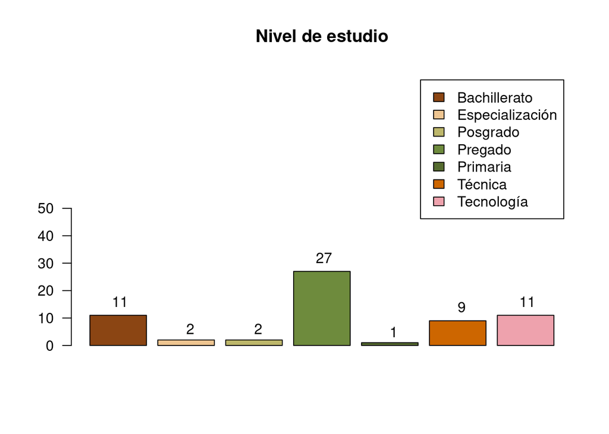

## Área de conocimiento

### Tabla de frecuencias

```
##
##  Ingenieria, arquitectura, urbanismo Economia, administracion, contaduria
##                                   27                                    8
##                              Ninguno          Ciencias sociales y humanas
##                                    8                                    5
##                         Bellas artes             Ciencias de la educación
##                                    4                                    3
##                 Ciencias de la salud      Matematicas, ciencias naturales
##                                    3                                    3
##    Agronomia, veterinaria, zootecnia
##                                    2
```

### Tabla de frecuencias de porcentajes

```
##
##  Ingenieria, arquitectura, urbanismo Economia, administracion, contaduria
##                            42.857143                            12.698413
##                              Ninguno          Ciencias sociales y humanas
##                            12.698413                             7.936508
##                         Bellas artes             Ciencias de la educación
##                             6.349206                             4.761905
##                 Ciencias de la salud      Matematicas, ciencias naturales
##                             4.761905                             4.761905
##    Agronomia, veterinaria, zootecnia
##                             3.174603
```

### Gráfica

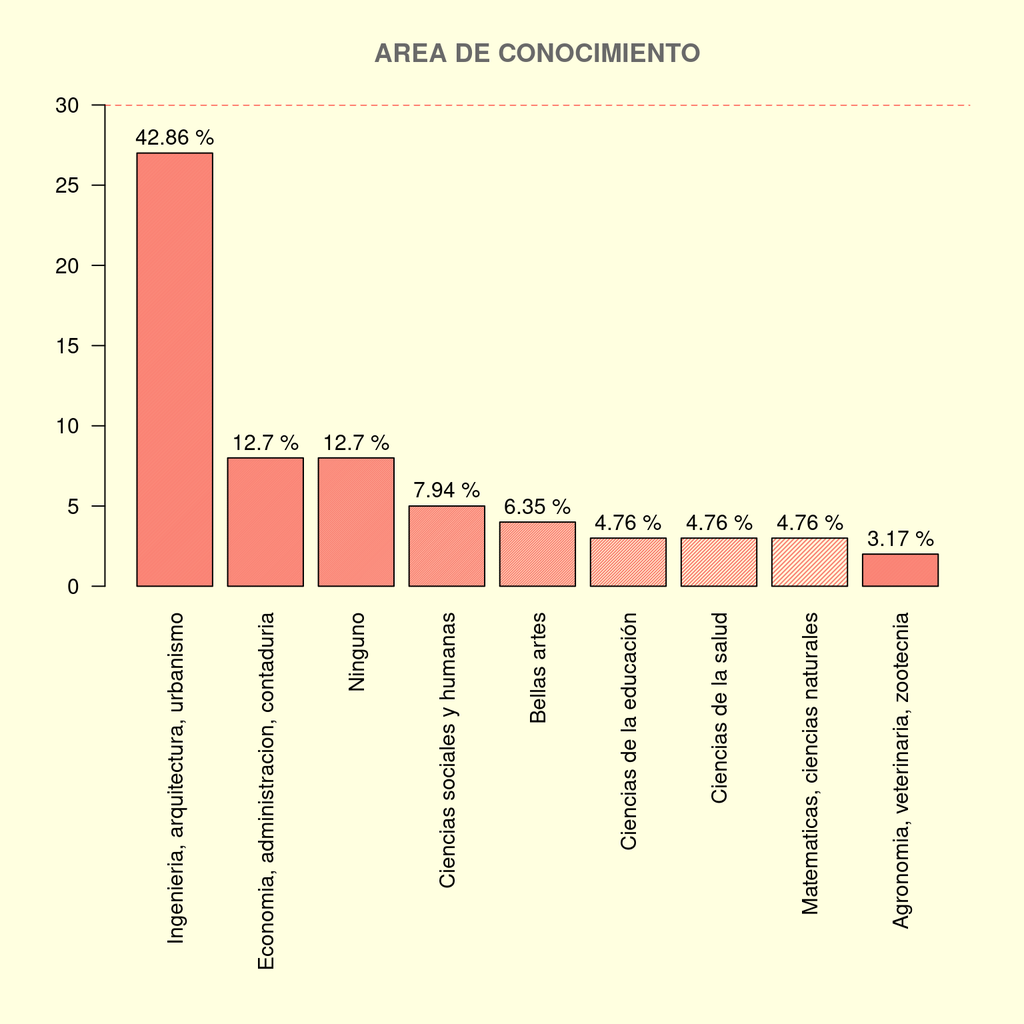

# Resultados

## Resultados a la pregunta tenemos un destino escrito

### Tabla de frecuencias

```
##
## Si No
## 35 28
```

### Tabla de frecuencias de porcentajes

```
##
##       Si       No
## 55.55556 44.44444
```

### Gráfica

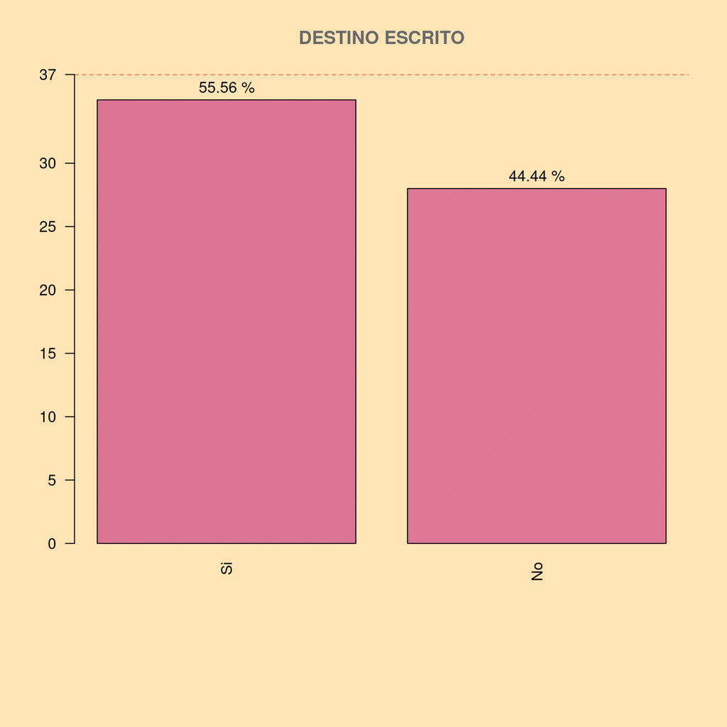

### Resultados se considera una persona religiosa

### Tabla de frecuencias

```
##
## No Si
## 21 42
```

### Tabla de frecuencias de porcentajes

```
##
##       No       Si
## 33.33333 66.66667
```

# Gráfica

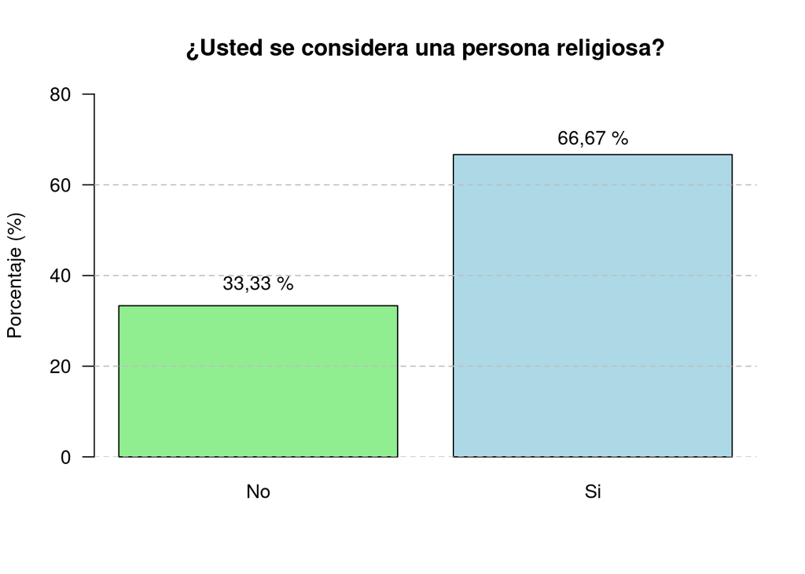

## Resultados escoger un número de 0 al 9

Esta fue una de las preguntas que se realizo en la encuesta, y como se puede observar en las tablas y en la grafica, el numero al azar que mas personas escogieron fue el 7, que es conocido como “el numero de la suerte”

### Tabla de frecuencias

```
##
##  0  1  2  3  4  5  6  7  8  9
##  2  2  7  8  3  8  9 11  8  5
```

### Tabla de frecuencias de porcentajes

```
##
##         0         1         2         3         4         5         6         7
##  3.174603  3.174603 11.111111 12.698413  4.761905 12.698413 14.285714 17.460317
##         8         9
## 12.698413  7.936508
```

### Gráfica

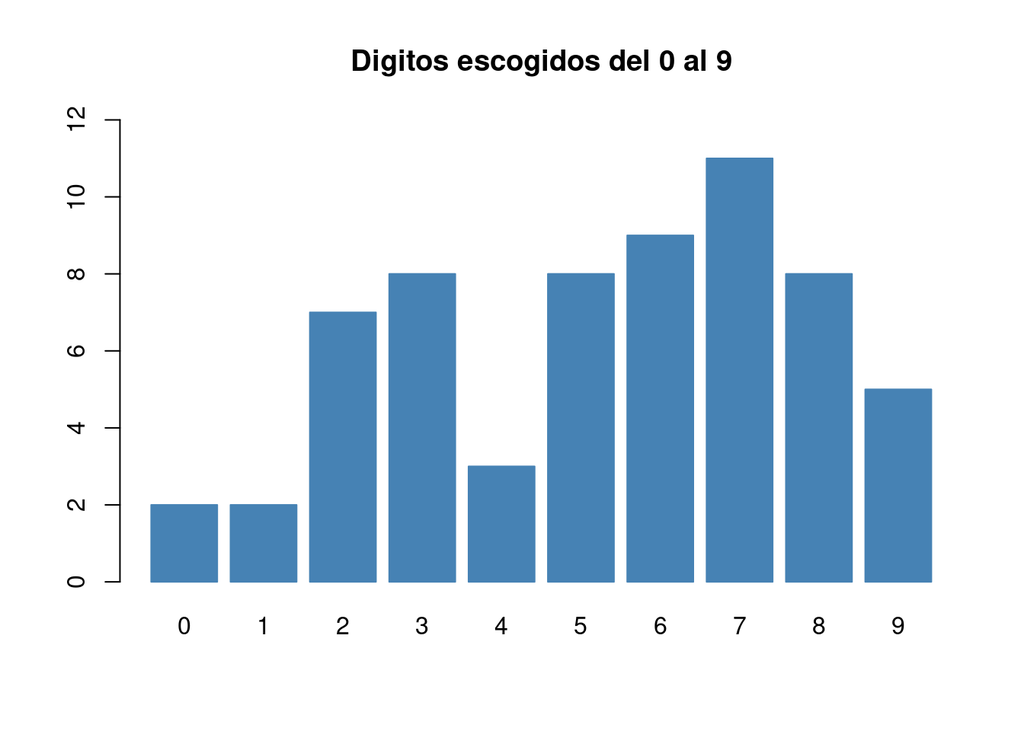